# HMMs: Non-Markovian data

Generate data with the hidden states $x_{1:T}$ generated as follows:

- Fix the number of breakpoints (e.g. 50)
- Draw breakpoints from the uniform distribution over $\{1, ..., n-1\}$ without replacement
- Assign class $1, ..., K=3$ to each segment independently.

### Non-Markovian Example 1

Generate observations with the emission probabilities ${\mathbf{B}}= \begin{pmatrix} 0.5 & 0 & 0 & 0.5 \\ 0 & 0 & 0.5 & 0.5 \\ 0.6 & 0.4 & 0 & 0 \end{pmatrix}$ A sequence of $x$ and $y$ of length $n=500$.

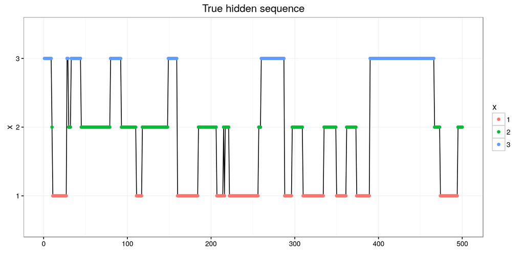

```r
B = rbind(c(0.5, 0, 0, 0.5), c(0, 0, 0.5, 0.5), c(0.6, 0.4, 0, 0))

n = 500
hmm_obs = generate_nonmarkov_seq(n, B, n_breakpoints = 50)
df_true = data.frame(t = 1:n, x = hmm_obs$x)
ggplot(df_true, aes(t, x, group=1)) +
  geom_path() + geom_point(aes(col = x)) +
  theme_bw() + xlab("") + ggtitle("True hidden sequence")
```

#### Inference

```r
res = gibbs_sampling_hmm(y = hmm_obs$y, n_hidden_states = nrow(B), alpha0 = 0.1, max_iter = 1500, burnin = 500)
```

```
## iter 100
## iter 200
## iter 300
## iter 400
## iter 500
## iter 600
## iter 700
## iter 800
## iter 900
## iter 1000
## iter 1100
## iter 1200
## iter 1300
## iter 1400
## iter 1500
```

```r
# relabel the latent states to obtain best match to the true B matrix
res_relabelled = match_states(res$trace_x, res$trace_A, res$trace_B, true_x = hmm_obs$x, k = nrow(B))
```

#### Visualise samples of $x_{1:T}$

Each draw from the posterior is shown as a grey line. The true states are shown as coloured points.

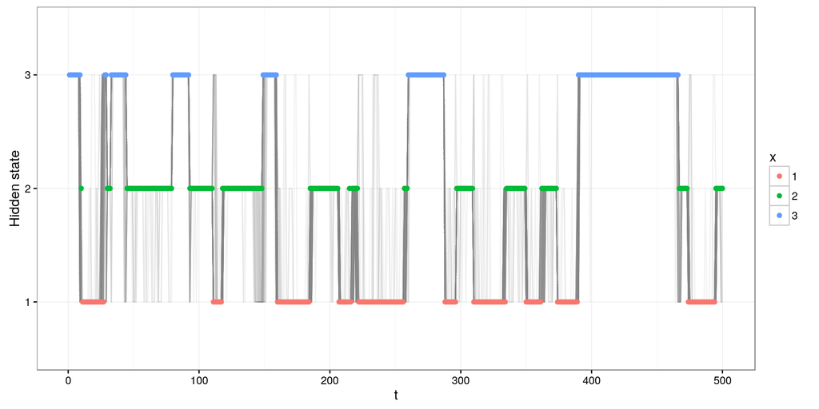

#### Traceplots of the elements in ${\mathbf{B}}$

Panel $(i, j)$ shows the traceplot for the element ${\mathbf{B}}_{ij}$. The red dotted line shows the true value.

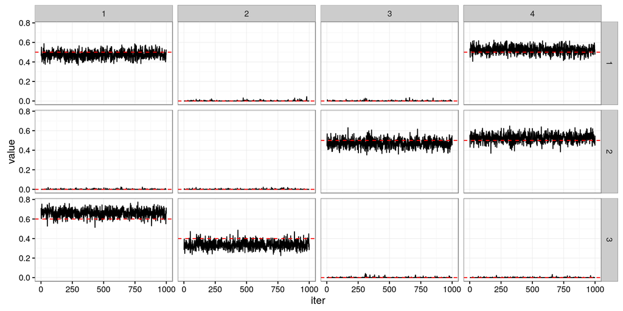

#### Visualise accuracy and switch rate

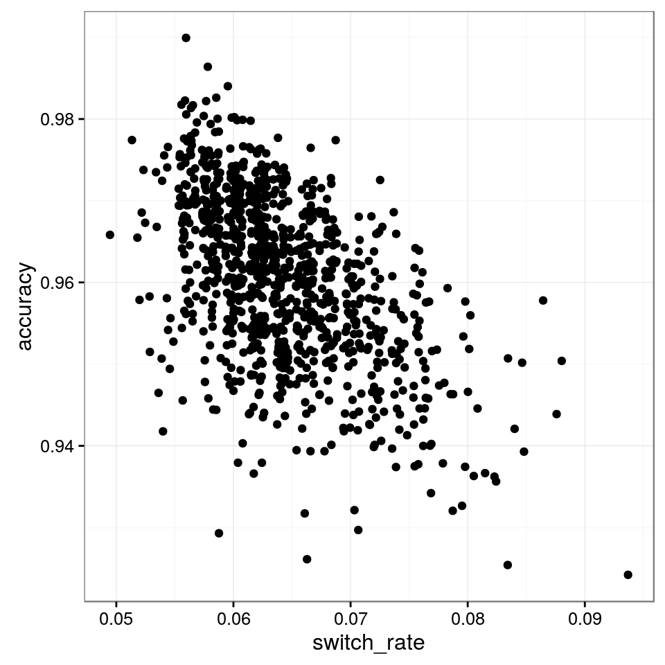

### Non-Markovian Example 2

Generate observations with the emission probabilities ${\mathbf{B}}= \begin{pmatrix} 0 & 0.1 & 0.35 & 0.55 \\ 0 & 0.1 & 0.45 & 0.45 \\ 0.6 & 0.3 & 0.1 & 0 \end{pmatrix}$ A sequence of $x$ and $y$ of length $n=500$.

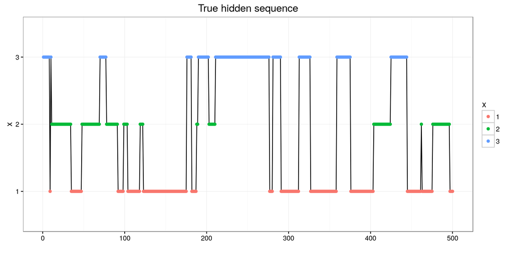

```r
B = rbind(c(0, 0.1, 0.45-0.1, 0.45+0.1), c(0, 0.1, 0.45, 0.45), c(0.6, 0.3, 0.1, 0))

n = 500
hmm_obs = generate_nonmarkov_seq(n, B, n_breakpoints = 50)
df_true = data.frame(t = 1:n, x = hmm_obs$x)
ggplot(df_true, aes(t, x, group=1)) +
  geom_path() + geom_point(aes(col = x)) +
  theme_bw() + xlab("") + ggtitle("True hidden sequence")
```

#### Inference

```r
res = gibbs_sampling_hmm(y = hmm_obs$y, n_hidden_states = nrow(B), alpha0 = 0.1, max_iter = 1500, burnin = 500)
```

```
## iter 100
## iter 200
## iter 300
## iter 400
## iter 500
## iter 600
## iter 700
## iter 800
## iter 900
## iter 1000
## iter 1100
## iter 1200
## iter 1300
## iter 1400
## iter 1500
```

```r
# relabel the latent states to obtain best match to the true B matrix
res_relabelled = match_states(res$trace_x, res$trace_A, res$trace_B, true_x = hmm_obs$x, k = nrow(B))
```

#### Visualise samples of $x_{1:T}$

Each draw from the posterior is shown as a grey line. The true states are shown as coloured points.

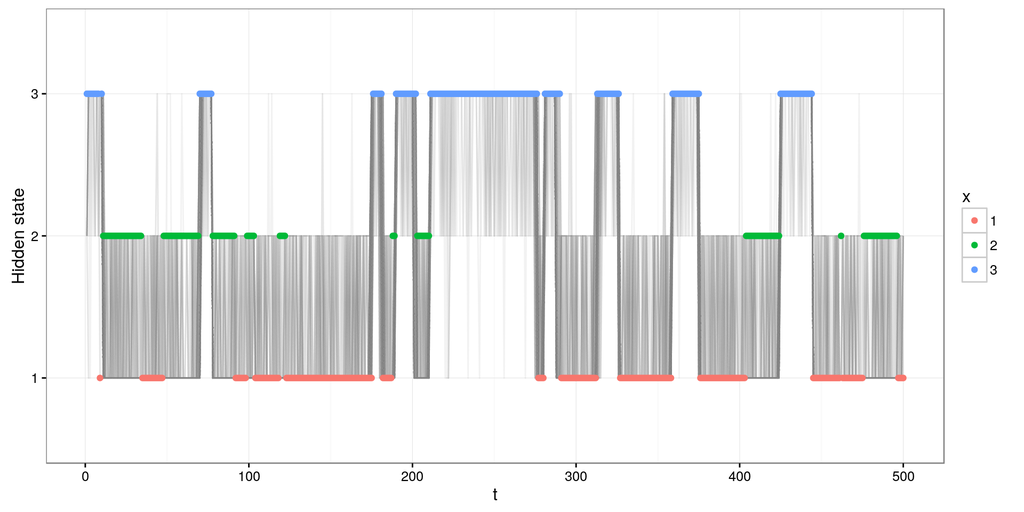

#### Traceplots of the elements in ${\mathbf{B}}$

Panel $(i, j)$ shows the traceplot for the element ${\mathbf{B}}_{ij}$. The red dotted line shows the true value.

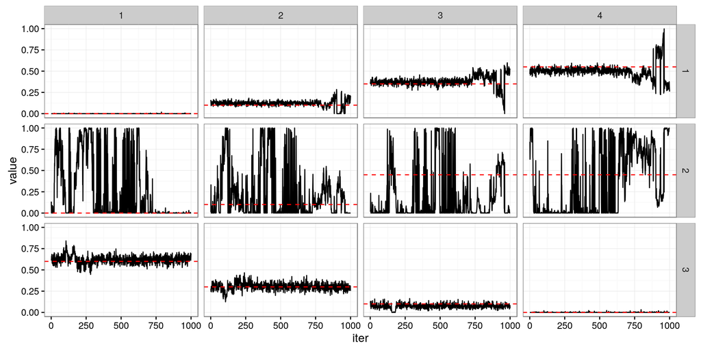

#### Visualise accuracy and switch rate

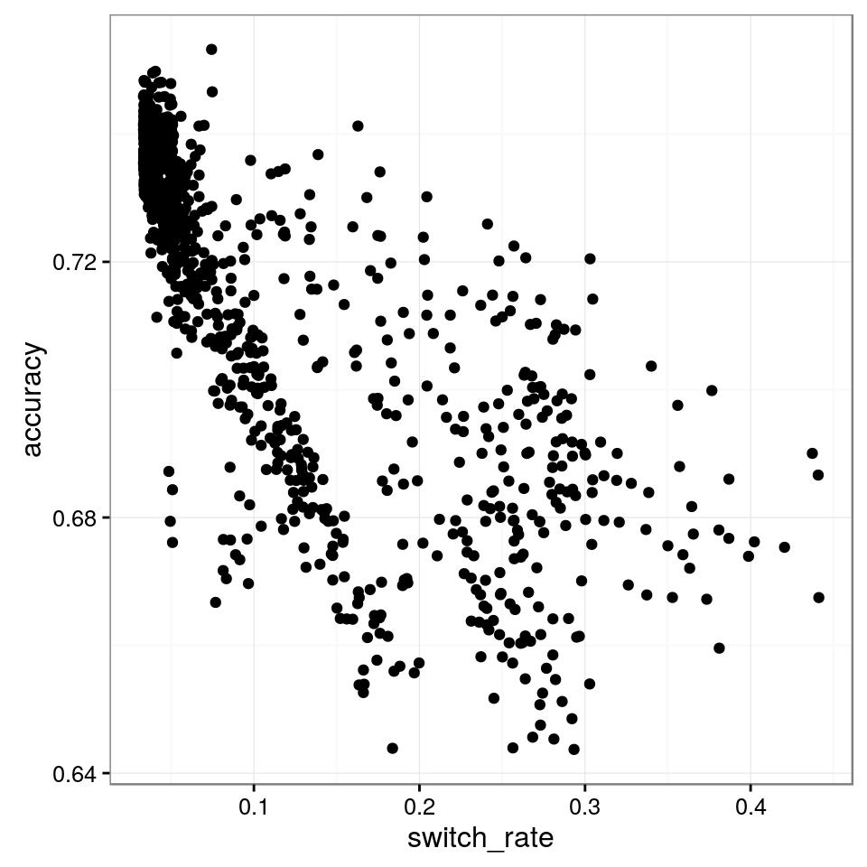